# Importancia de los sistemas de referencia de coordenadas en ecología

# 6 Recomendacion (4): Considerar cómo influye la resolución espacial y los píxeles mezclados en nuestros resultados

En ecología, solemos combinar datos espaciales de distintas resoluciones, cada uno con sus incertidumbres asociadas, para explicar o predecir patrones ecológicos. El problema surge cuando utilizamos datos de resolución gruesa, o los relacionamos con datos de resolución fina, para extraer conclusiones sobre procesos que ocurren a escalas pequeñas. Un píxel de resolución gruesa puede incluir distintas coberturas del suelo, como bosque y zonas sin bosque, de modo que su valor representa esa mezcla (a eso le llamamos “píxel mixto”). Si no tenemos esto en cuenta, podemos atribuir a un proceso ecológico local un patrón que se debe, al menos en parte, a la mezcla de coberturas.

Para ilustrarlo, tomaremos como referencia el estudio de Chaplin-Kramer et al. (2015), *«Degradation in carbon stocks near tropical forest edges»*. En este trabajo, los investigadores combinaron datos ráster de cobertura del suelo con una resolución de 30 m y datos de biomasa con una resolución de 500 m, y observaron una disminución de la biomasa cerca de los bordes del bosque.

Vamos a ver con el siguiente código lo que estaba pasando. Primero, vamos a crear la cobertura del suelo a 30 m.

```r
cobertura_30 <- rast(
  xmin = 500000, xmax = 503000,
  ymin = 4480000, ymax = 4483000,
  resolution = 30, crs = "EPSG:25830"
)
xy <- crds(cobertura_30)
borde_x <- 501200
values(cobertura_30) <- as.integer(xy[, 1] >= borde_x)
names(cobertura_30) <- "bosque"
cobertura_factor <- cobertura_30
levels(cobertura_factor) <- data.frame(
  ID = c(0, 1), cobertura = c("No bosque", "Bosque")
)
```

Vamos a suponer la siguiente que la biomasa se mantiene constante y asignamos 200 Mg/ha a todas las celdas de bosque y 0 a las de no bosque. En esta situación, vemos que la biomasa no disminuye al acercarnos al borde.

```r
biomasa_30 <- cobertura_30 * 200
names(biomasa_30) <- "biomasa"
```

Resampleamos los datos de biomasa de 30 m a 500 m de resolución, que es el tamaño de píxel con el que los investigadores realizaron sus analisis. Esto sería lo que a menudo nos referimos con un upscaling.

```r
plantilla_500 <- rast(
  ext(cobertura_30), resolution = 500, crs = crs(cobertura_30)
)
biomasa_500 <- resample(biomasa_30, plantilla_500, method = "average")
fraccion_bosque_500 <- resample(
  cobertura_30, plantilla_500, method = "average"
)
names(biomasa_500) <- "biomasa"
```

Qué pasa si volvemos a 30 m? Repetimos el valor de la celda gruesa sobre la cuadrícula fina mediante vecino más próximo. Lo usamos para mostrar de dónde viene cada valor, no como método para estimar nueva variación local de biomasa.

```r
biomasa_500_a_30 <- resample(
  biomasa_500, cobertura_30, method = "near"
)
```

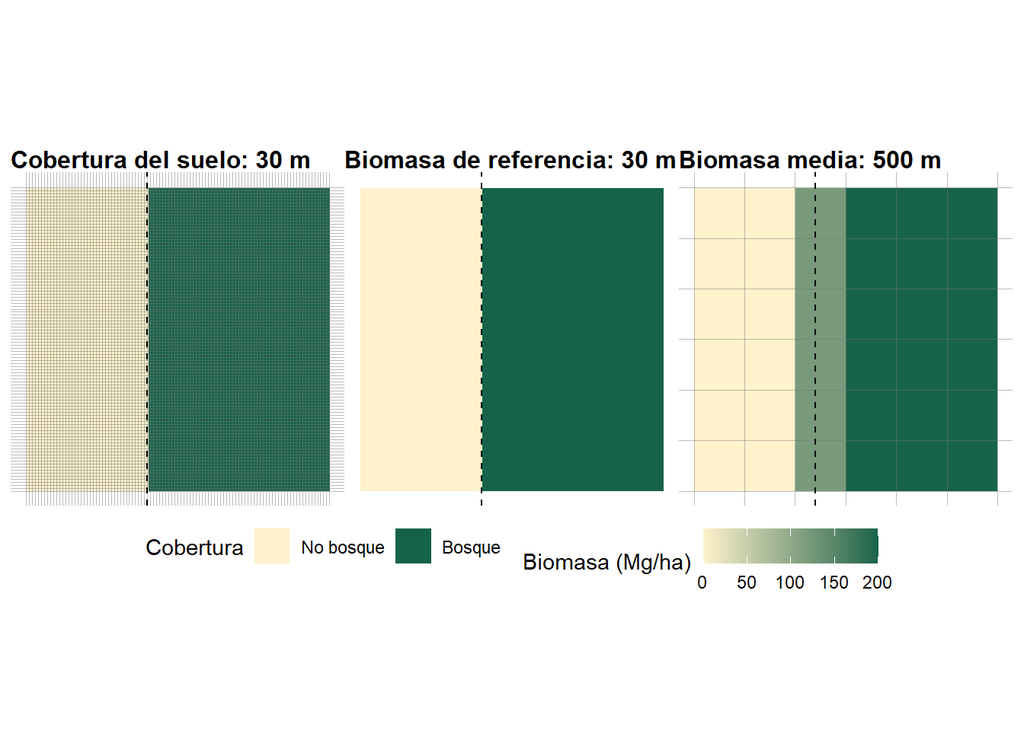

```r
# Elementos comunes a los cuatro mapas
elementos_comunes <- list(
  geom_vline(
    xintercept = borde_x,
    linetype = "dashed",
    linewidth = 0.5),
  theme_void(),
  theme(
    plot.title = element_text(size = 12, face = "bold"),
    legend.position = "bottom"
  )
)


# Cobertura del suelo: categorías
p_cobertura <- ggplot() +
  geom_spatraster(data = cobertura_factor) +
  scale_fill_manual(
    values = c("No bosque" = "#FFF2CC", "Bosque" = "#16634A"),
    name = "Cobertura"
  ) +

  geom_vline(
    xintercept = seq(
      terra::xmin(cobertura_factor),
      terra::xmax(cobertura_factor),
      by = terra::res(cobertura_factor)[1]
    ),
    colour = "#77777780",
    linewidth = 0.15
  ) +
  geom_hline(
    yintercept = seq(
      terra::ymin(cobertura_factor),
      terra::ymax(cobertura_factor),
      by = terra::res(cobertura_factor)[2]
    ),
    colour = "#77777780",
    linewidth = 0.15
  ) +
  elementos_comunes +
  labs(title = "Cobertura del suelo: 30 m")

# Cobertura del suelo: categorías
p_biomasa_30 <- ggplot() +
  geom_spatraster(data = biomasa_30) +
  scale_fill_gradient(
    low = "#FFF2CC",
    high = "#16634A",
    limits = c(0, 200),
    name = "Biomasa (Mg/ha)"
  ) +
  elementos_comunes +
  labs(title = "Biomasa de referencia: 30 m")

# Biomasa a 500 m, mostrando los límites de las celdas
p_biomasa_500 <- ggplot() +
  geom_spatraster(data = biomasa_500) +
  geom_vline(
    xintercept = seq(500000, 503000, 500),
    colour = "#77777780",
    linewidth = 0.3
  ) +
  geom_hline(
    yintercept = seq(4480000, 4483000, 500),
    colour = "#77777780",
    linewidth = 0.3
  ) +
  scale_fill_gradient(
    low = "#FFF2CC",
    high = "#16634A",
    limits = c(0, 200),
    name = "Biomasa (Mg/ha)"
  ) +
  elementos_comunes +
  labs(title = "Biomasa media: 500 m")

# Combinar los cuatro mapas y compartir las leyendas
(p_cobertura  + p_biomasa_30 +
    p_biomasa_500 +
    plot_layout(guides = "collect")
) & theme(legend.position = "bottom")
```

¿Qué estaba pasando realmente? Los píxeles cubrías los bordes forestales incluir información tanto de bosque como superficies no forestales. Por tanto, el valor de la biomasa en ese pixel era menor simplemente porque contenía menos superficie de bosque.

[figure not shown]

(Fuente: https://commons.wikimedia.org/wiki/File:Mixed_pixel.svg)

# 7 Otras consideraciones: ¿Cómo exportar datos espaciales?

## 7.1 ¿En qué formato guardo mis datos espaciales?

El formato de almacenamiento determina qué información puede guardar un archivo y con qué programas podemos utilizarlo. Distinguimos entre formatos **vectoriales** y **ráster**.

### 7.1.1 *Formatos vectoriales*

Los datos vectoriales representan elementos mediante puntos, líneas o polígonos, junto con sus atributos.

| Formato | Extensión | Cuándo utilizarlo | Consideraciones |
| --- | --- | --- | --- |
| **GeoPackage** | `.gpkg` | Opción general recomendada para guardar e intercambiar capas de muestreos, parcelas, hábitats o límites. | Un único archivo puede contener varias capas. Conserva geometrías, atributos y SRC. |
| **Shapefile** | `.shp` y archivos asociados | Cuando lo exige un programa antiguo o el destinatario. | Necesita varios archivos; limita los nombres de campos a 10 caracteres y tiene restricciones en los tipos de datos. |
| **GeoJSON** | `.geojson` | Intercambio de datos con aplicaciones y mapas web. | Es un formato de texto; puede ocupar mucho espacio. El estándar utiliza coordenadas geográficas WGS84 en orden longitud, latitud. |
| **KML / KMZ** | `.kml` / `.kmz` | Visualizar y compartir información en Google Earth. | Utiliza coordenadas WGS84. Está orientado a la presentación; no es la primera opción para conservar datos de análisis. |
| **CSV** | `.csv` | Compartir tablas de muestreos con columnas de coordenadas. | No es un formato espacial por sí mismo. Debemos documentar las columnas de coordenadas, sus unidades y el SRC. |

Para la mayoría de los trabajos vectoriales en QGIS o R, GeoPackage es una buena opción.

Un Shapefile no es únicamente el archivo `.shp`: normalmente debemos conservar y compartir también `.shx`, `.dbf` y `.prj`, además de otros archivos asociados que puedan existir.

### 7.1.2 *Formatos ráster*

Los datos ráster representan el territorio mediante una cuadrícula de celdas, como ocurre con una imagen satelital, un modelo de elevaciones o una capa de temperatura.

| Formato | Extensión | Cuándo utilizarlo | Consideraciones |
| --- | --- | --- | --- |
| **GeoTIFF** | `.tif` / `.tiff` | Opción general para guardar variables ambientales, modelos de elevaciones e imágenes. | Puede guardar varias bandas, georreferenciación y SRC. Admite compresión sin pérdida. |
| **Cloud Optimized GeoTIFF — COG** | `.tif` / `.tiff` | Consultar rásteres grandes alojados en servidores o almacenamiento en la nube. | Es un GeoTIFF organizado para leer partes del archivo sin descargarlo completo. No todo GeoTIFF es un COG. |
| **NetCDF** | `.nc` | Datos climáticos u oceanográficos con dimensiones como tiempo, profundidad o altura. | Adecuado para almacenar múltiples variables y series temporales; la interpretación depende de sus metadatos y convenciones. |
| **ASCII Grid** | `.asc` | Intercambiar cuadrículas sencillas con herramientas que requieren este formato. | Es texto, suele ocupar mucho espacio y normalmente almacena una sola variable. El SRC puede requerir un archivo auxiliar. |

Para un ráster ambiental individual, GeoTIFF suele ser una buena opción. Para datos con muchas fechas o dimensiones, NetCDF puede ser más adecuado.

- **SRC:** el archivo debe conservarlo o ir acompañado de una descripción explícita.
- **Tipo de dato:** guardar valores decimales como enteros puede provocar pérdida de información.
- **Valores sin datos:** hay que distinguir los valores ausentes (`NoData`) de valores válidos como el cero.
- **Compresión:** para conservar valores de análisis, utilizar compresión sin pérdida.
- **Resolución y extensión:** cambiar el formato no debería confundirse con cambiar el tamaño de las celdas, recortar o reproyectar.

Otra consideración importante al exportar un archivo ráster es elegir un tipo de dato que permita representar todo su rango de valores con la precisión necesaria. Por ejemplo, si un ráster contiene valores entre −99.999 y 99.999, no podemos guardarlo como Int16, cuyo rango va de −32.768 a 32.767. En ese caso, podríamos usar el Int32. Tampoco conviene utilizar Float64 cuando no representar tango ranfgo de datos, ya que requerirá más espacio de almacenamiento por píxel.

| Tipo de dato | Rango de valores |
| --- | --- |
| **Byte** | De **0 a 255** |
| **Int16** | De **−32.768 a 32.767** |
| **UInt16** | De **0 a 65.535** |
| **UInt32** | De **0 a 4.294.967.295** |
| **Int32** | De **−2.147.483.648 a 2.147.483.647** |
| **Float32** | De −3,4028235 × 10³⁸ a +3,4028235 × 10³⁸ |
| **Float64** | −1,7976931348623157 × 10³⁰⁸ a +1,7976931348623157 × 10³⁰⁸ |

## 7.2 Exportar archivos vectoriales y raster en R

Guardamos el ráster de temperatura como GeoTIFF, utilizando Float32 para conservar valores decimales y compresión LZW, sin pérdida.

```r
# Guardar ráster -------------------------------------------------------------

terra::writeRaster(
  r_temperatura,
  filename = "temperatura.tif",
  datatype = "FLT4S",
  gdal = "COMPRESS=LZW",
  overwrite = TRUE
)
```

Guardamos la capa vectorial de muestreos como GeoPackage, conservando sus geometrías, atributos y SRC.

```r
# Guardar muestreos -----------------------------------------------------------

sf::st_write(
  muestreos_wgs84,
  dsn = "muestreos.gpkg",
  layer = "muestreos",
  delete_layer = TRUE
)
```

```
Deleting layer `muestreos' using driver `GPKG'
Writing layer `muestreos' to data source `muestreos.gpkg' using driver `GPKG'
Writing 8 features with 2 fields and geometry type Point.
```

## 7.3 Lista de comprobaciones finales

```
LISTA DE COMPROBACIONES ANTES DE UN ANÁLISIS ESPACIAL

1. ¿Todos los objetos tienen un SRC definido?
2. ¿El EPSG asignado describe realmente las coordenadas?
3. ¿El SRC es adecuado para la localización del estudio?
4. ¿Las unidades son apropiadas para medir distancias o áreas?
5. ¿Todos los objetos utilizan SRC compatibles?
6. ¿Se ha utilizado st_transform() o project() para transformar?
7. ¿El método de remuestreo es adecuado para la variable?
8. ¿Se ha evitado reproyectar repetidamente los datos?
9. ¿Se ha registrado el SRC original y el SRC del análisis?
10. ¿El código EPSG se incluye en métodos y metadatos?
```